# **MIE1517 Group Project: Smile Transfer**

## **Team 2, Fall 2021**

### Trevor Zhuang, Jiangfeng Ding, and Katie Allison

# Summary of Project and Progress

The goal of our project is to transfer happy facial expressions to individuals in group photos with unhappy facial expressions. Specifically, our objectives are to:

- detect and localize individual faces in images with more than one distinct face visible
- perform binary classification to classify each face in each image as "happy" or "not happy" (where "not happy" expressions may be any of seven distinct primary emotional expressions including "neutral", "sad", "contempt", etc.)
- perform image feature transfer to transfer "happy" expressions onto faces that have "not happy" expressions

We plan to use existing packages directly for the face localization aspect to allow us to focus on the classification and generation aspects of the project.

**At the time of the project progress report, our team has:**

- obtained all training and validation data (from AffectNet database)
- come up with a reasonable model for binary classification
- tested the classifier with very promising results (75% accuracy on new data and 88% accuracy on training set)
- come up with a reasonable model for expression transfer (using a PyTorch implementation of the GANimation architecture)
- generated some promising results using an open-source PyTorch implementation of the GANimation architecture to show GANimation functionality (image that shows man's facial expression changing)

**The tasks that remain are:**

- implementing an out-of-the-box solution to detect and localize individual faces that can be cropped for use in image feature transfer
- tuning GANimation implementation using our own version of the current GANimation model architecture to improve performance of "happy" expression transfer

We believe it will be feasible to complete the project within the time available. The implementation of an out-of-the-box solution for face detection and localization should be straightforward. The tuning of the GANimation for expression transfer is less predictable, and may take significant amounts of time, but the image that we have already generated that shows a partially transferred facial expression is already promising.

The data used for training our model is loaded and converted to use binary (happy or not happy) labels in Part 1. The classifier code and some classification results are shown in Part 2. The start of our GANimation implementation results (pictures showing what GANimation does with our data out-of-the-box) are given in Part 3 along with a link to the GitHub repository for the GANimation PyTorch code that we are using as our template.

# Part 1: Set up and Loading Training Data

The training data used for our classifier was obtained by request from AffectNet. The AffectNet dataset that we obtained contains over 280,000 training samples and 4,000 validation samples. The samples are categorized by emotion, with integer mapping to eight emotions: neutral, happy, sad, angry, disgust, surprise, contempt, and fear. Since we only care about turning non-happy images into happy images for our project, we concatenated the seven non-happy samples into a single set of non-happy samples. This worked out well because the happy label had by far the highest number of samples anyways and so combining the other seven labels evened the scales.

## Loading packages and setting label mapping

```python
# import libraries
import os
import time
import torch
import torch.nn as nn
import torch.nn.functional as F
import torch.optim as optim
import numpy as np
import pandas as pd
from tqdm import tqdm
import matplotlib.pyplot as plt
from torchvision import transforms
import torchvision.models
from torchvision.io import read_image
from torch.utils.data import Dataset, DataLoader
import re
import seaborn as sns
from tqdm import tqdm
import tarfile
import matplotlib.image as image
```

```python
# set mapping from string indicating emotion category to integer label (original and binary)
labels_encoder = {0: "Neutral", 1: "Happy", 2: "Sad", 3:"Surprise",
                  4: "Fear", 5: "Disgust", 6: "Anger", 7: "Contempt"}

labels_encoder_binary = {0: "Non-Happy", 1: "Happy"}
```

## Uploading and unzipping organized dataset

```python
from google.colab import drive
drive.mount('/content/gdrive',force_remount=True)
```

```python
def unzip_tar_file(source_path,destination_path):
    '''
    Read contents of .tar file into memory in Google Colab.
    '''
    zip_ref = tarfile.TarFile(source_path, 'r')
    zip_ref.extractall(destination_path)
    zip_ref.close()

def load_images_from_folder(folder,s,cnn = False):
    '''
    Read data images and their expression label (integer) in from folder.
    '''
    # get list of image filenames
    images = []
    labels = []
    imagefolder = folder+'/images'
    k = os.listdir(imagefolder)[:s]

    # read in all images and labels from folder
    for filename in k:
        # add image to list
        img = plt.imread(os.path.join(folder+'/images',filename))
        if img is not None:
            images.append(img)

        # get filename for label for this image ('exp' files give expression label as int)
        number = int(re.search(r'\d+',  filename)[0])
        label_filename = folder+'/annotations/'+str(number)+'_exp.npy'

        # get expression label and add to list, or label as "not face" and warn if label not found
        if os.path.isfile(label_filename):
            label = np.load(label_filename)
        else:
            label = 10
            print("Label for image %s not found"%filename)
        labels.append(int(label))

    images = np.array(images)
    print("Shape of images is ",np.shape(images))
    labels = np.array(labels)
    print("Shape of labels is ",np.shape(labels))

    if cnn:
      images = np.transpose(torch.tensor(images),[0,3,2,1])
      trainfeature= resnet(images/255)
      trainfeature = [x.clone().detach() for x in trainfeature]
      data = zip(trainfeature, labels)
      data = list(data)

    else:
      images = np.transpose(torch.tensor(images),[0,3,2,1])
      images = images/255
      images = [x.clone().detach() for x in images]
      data = zip(images, labels)
      data =  list(data)

    return data,images
```

```python
train_path = '/content/gdrive/MyDrive/Colab Notebooks/Project/data/train_set.tar'
valid_path = '/content/gdrive/MyDrive/Colab Notebooks/Project/data/val_set.tar'
unzip_tar_file(train_path, '/content')
unzip_tar_file(valid_path, '/content')

traindata = load_images_from_folder('train_set',4000,cnn = False)
print("Shape of training data: ")
print(np.shape(traindata))

valdata = load_images_from_folder('val_set',400,cnn = False)
print("Shape of validation data: ")
print(np.shape(valdata))
```

```
Shape of images is  (4000, 224, 224, 3)
Shape of labels is  (4000,)
Shape of training data:
(2, 4000)
```

```
Shape of images is  (400, 224, 224, 3)
Shape of labels is  (400,)
Shape of validation data:
(2, 400)
```

## Showing categories and binarizing dataset labels

```python
def make_labelled_dataframe(path,lbl_extension,img_extension):
    '''
    Imports all images and labels from directory "path" to annotation (label)
    information and makes dataframe with all image filenames and their labels
    '''
    # add all filenames and labels to list
    labels_data = []
    for filename in tqdm(os.listdir(path)):
        if filename.endswith('_exp.npy'):
            img_filename = filename.replace(lbl_extension,img_extension)
            labels_data.append([img_filename, np.load(path+filename).item()])

    # convert list to DataFrame
    labels_dataframe = pd.DataFrame(labels_data)
    labels_dataframe[1] = labels_dataframe[1].astype('int32')

    return labels_dataframe

def make_binary_dataframe(labels_dataframe,happy_ind_int,nonhappy_ind_list):
    '''
    Takes in dataframe with all filenames and labels and splits into equally sized
    happy and non-happy dataframes, then reassigns labels as 0=nonhappy, 1=happy and
    concatenates to make a binary dataframe.
    '''
    # get N, min number of training samples that have happy vs unhappy faces
    num_happy = np.count_nonzero(labels_dataframe[1] == happy_ind_int)
    num_nonhappy = np.count_nonzero(labels_dataframe[1] != happy_ind_int)
    min_num = min(num_happy,num_nonhappy)

    #print(num_happy)
    #print(num_nonhappy)

    # get N happy samples
    happy_mask = labels_dataframe[1]==happy_ind_int
    happy_df = labels_dataframe[happy_mask].sample(frac=1).iloc[:min_num]
    #print(happy_df.info())

    # get all unhappy samples, limit to N samples, and set new label to 0
    nonhappy_mask = labels_dataframe[1].isin(nonhappy_ind_list)
    nonhappy_df = labels_dataframe[nonhappy_mask].sample(frac=1).iloc[:min_num]
    nonhappy_df[1] = 0
    #print(nonhappy_df.info())

    # create a balanced dataframe
    balanced_dataframe = pd.concat([happy_df,nonhappy_df])
    print(balanced_dataframe.info())
    #print(balanced_dataframe)

    return balanced_dataframe
```

### Visualizing and binarizing training data

```
<class 'pandas.core.frame.DataFrame'>
RangeIndex: 287651 entries, 0 to 287650
Data columns (total 2 columns):
 #   Column  Non-Null Count   Dtype
---  ------  --------------   -----
 0   0       287651 non-null  object
 1   1       287651 non-null  int32
dtypes: int32(1), object(1)
memory usage: 3.3+ MB
None
```

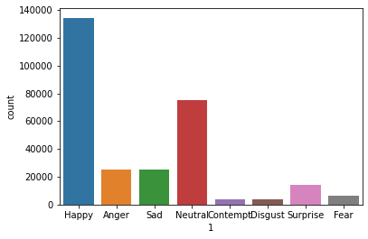

```python
# train set data visualization
train_dir = 'train_set/annotations/'
labels_df = make_labelled_dataframe(train_dir,'_exp.npy','.jpg')
print(labels_df.info())

# plot data architecture before binarization
sns.countplot(labels_df[1].map(labels_encoder))
```

```
<class 'pandas.core.frame.DataFrame'>
Int64Index: 268830 entries, 119542 to 88329
Data columns (total 2 columns):
 #   Column  Non-Null Count   Dtype
---  ------  --------------   -----
 0   0       268830 non-null  object
 1   1       268830 non-null  int64
dtypes: int64(1), object(1)
memory usage: 6.2+ MB
None
```

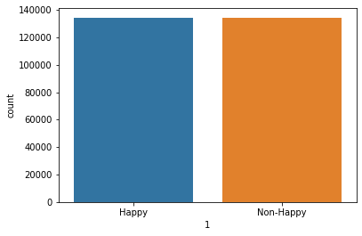

```python
index_happy = 1
indices_nonhappy = [0,2,3,4,5,6,7]
balanced_df = make_binary_dataframe(labels_df,index_happy,indices_nonhappy)

# plot data architecture after binarization
sns.countplot(balanced_df[1].map(labels_encoder_binary))
```

```python
balanced_df.to_csv(train_dir+'labels.csv', index=False)
print("labels.csv created at "+train_dir)
```

```
labels.csv created at train_set/annotations/
```

### Visualizing and binarizing validation data

```
<class 'pandas.core.frame.DataFrame'>
RangeIndex: 3999 entries, 0 to 3998
Data columns (total 2 columns):
 #   Column  Non-Null Count  Dtype
---  ------  --------------  -----
 0   0       3999 non-null   object
 1   1       3999 non-null   int32
dtypes: int32(1), object(1)
memory usage: 47.0+ KB
None
```

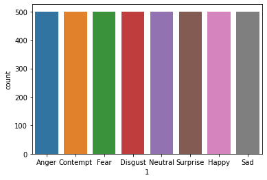

```python
# valid set data visualization
valid_dir = 'val_set/annotations/'
labels_df = make_labelled_dataframe(valid_dir,'_exp.npy','.jpg')
print(labels_df.info())

# plot data architecture before binarization
sns.countplot(labels_df[1].map(labels_encoder))
```

```
<class 'pandas.core.frame.DataFrame'>
Int64Index: 1000 entries, 3984 to 733
Data columns (total 2 columns):
 #   Column  Non-Null Count  Dtype
---  ------  --------------  -----
 0   0       1000 non-null   object
 1   1       1000 non-null   int64
dtypes: int64(1), object(1)
memory usage: 23.4+ KB
None
```

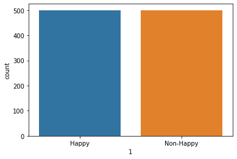

```python
balanced_df = make_binary_dataframe(labels_df,index_happy,indices_nonhappy)

# plot data architecture after binarization
sns.countplot(balanced_df[1].map(labels_encoder_binary))
```

```python
balanced_df.to_csv(valid_dir+'labels.csv', index=False)
print("labels.csv created at "+valid_dir)
```

```
labels.csv created at val_set/annotations/
```

# Part 2: Binary Emotion Classification

With the binarized dataset, we then implement a binary classifier. Our model uses a pretrained AlexNet model as a feature extractor, then uses a fully connected linear neural net to classify the image as either a "happy" facial expression or a "not happy" facial expression using the extracted features as input.

Our augmented dataset contains the AffectNet data (used for training and validation) as well as new data from the combined FER, CK Plus, and KDEF datasets found here: https://www.kaggle.com/sudarshanvaidya/corrective-reannotation-of-fer-ck-kdef. This new data is loaded and binarized using the same process that was used to show the loading and binarization of the AffectNet data in Part 1 above. Note that some filepaths change from Part 1 to Part 2 -- this is because this progress update file is an amalgation of multiple notebooks which are used collectively in a modular way.

## Data loading setup

### Dataset classes for AffectNet data and new data

```python
# create dataset class for AffectNet
class AffectNetImageDataset(Dataset):
    """AffectNet Facial Expressions Dataset"""

    def __init__(self, annotations_file, img_dir, transform=None):
        """
        Args:
            annotations_file: Path to the csv file with annotations.
            img_dir: Directory with all the images.
            transform (callable, optional): Optional transform to be applied on a sample.
        """

        self.img_labels = pd.read_csv(annotations_file)
        self.img_dir = img_dir
        self.transform = transform

    def __len__(self):
        return len(self.img_labels)

    def __getitem__(self, idx):
        img_path = os.path.join(self.img_dir, self.img_labels.iloc[idx, 0])
        image = read_image(img_path)
        label = self.img_labels.iloc[idx, 1]
        if self.transform:
            image = self.transform(image)
        return image, label

# create dataset class for fer_ckplus_kdef
class fer_ckplus_kdefImageDataset(Dataset):
    """fer_ckplus_kdef Facial Expressions Dataset"""

    def __init__(self, annotations_file, img_dir, transform=None):
        """
        Args:
            annotations_file: Path to the csv file with annotations.
            img_dir: Directory with all the images.
            transform (callable, optional): Optional transform to be applied on a sample.
        """

        self.img_labels = pd.read_csv(annotations_file)
        self.img_dir = img_dir
        self.transform = transform

    def __len__(self):
        return len(self.img_labels)

    def __getitem__(self, idx):
        img_path = os.path.join(self.img_dir, self.img_labels.iloc[idx, 0])
        image = read_image(img_path)
        image = torch.stack([image, image, image]).squeeze() # convert 1 channel to 3 channel to match with model
        label = self.img_labels.iloc[idx, 1]
        if self.transform:
            image = self.transform(image)
        return image, label

# resize all images to 224 x 224
transform = transforms.Compose([transforms.CenterCrop(224),
                                transforms.Grayscale(3)])

train_data = AffectNetImageDataset(annotations_file='./data/train_set/annotations/labels.csv',
                                   img_dir='./data/train_set/images/',
                                   transform=transform)
val_data = AffectNetImageDataset(annotations_file='./data/val_set/annotations/labels.csv',
                                   img_dir='./data/val_set/images/',
                                   transform=transform)
test_data = fer_ckplus_kdefImageDataset(annotations_file='./data/test_set/annotations/labels.csv',
                                   img_dir='./data/test_set/images/',
                                   transform=transform)

# print out some data stats
print('Num training images: ', len(train_data))
print('Num validation images: ', len(val_data))
print('Num testing images: ', len(test_data))
```

```
Num training images:  52500
Num validation images:  980
Num testing images:  1820
```

### Dataloader definition

```python
# create dataloader
###########################################################
# put this in training function if batch_size is a training fuction parameter
###########################################################
def get_data_loader(data, batch_size=64, num_workers=16):
    data_loader = DataLoader(data, batch_size=batch_size, num_workers=num_workers, shuffle=True, pin_memory=True)
    return data_loader

# Fixed PyTorch random seed for reproducible result
torch.manual_seed(1000)

# Obtain the PyTorch data loader objects to load batches of the datasets
train_loader = get_data_loader(train_data, batch_size=64, num_workers=16)
val_loader = get_data_loader(val_data, batch_size=64, num_workers=16)
test_loader = get_data_loader(test_data, batch_size=64, num_workers=16)
```

## Sample data visualization

### Visualization of sample images from the training set

```
Visualize TRAIN images
```

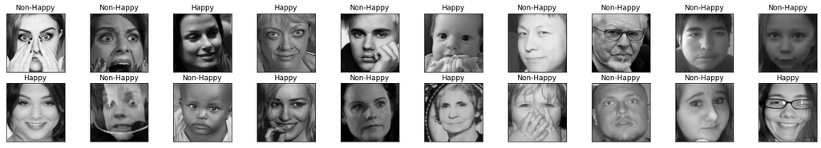

```python
# Visualize some data images
labels_encoder_binary = {0: "Non-Happy", 1: "Happy"}

####################################
# display TRAIN images
print("Visualize TRAIN images")
# obtain one batch of images
dataiter = iter(train_loader)
images, labels = dataiter.next()
images = images.numpy() # convert images to numpy for display
labels = labels.numpy() # convert labels to numpy for display

# plot the images in the batch, along with the corresponding labels
fig = plt.figure(figsize=(25, 4))
for idx in np.arange(20):
    ax = fig.add_subplot(2, 20/2, idx+1, xticks=[], yticks=[])
    plt.imshow(np.transpose(images[idx], (1, 2, 0)))
    ax.set_title(labels_encoder_binary[labels[idx]])
```

### Visualization of sample images from the validation set

```
Visualize VALID images
```

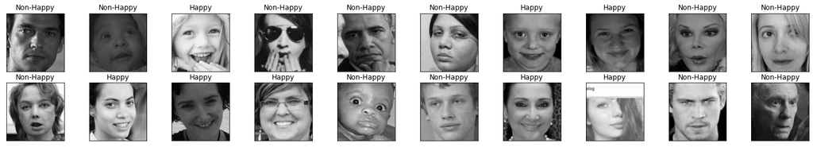

```python
####################################
# display VALID images
print("Visualize VALID images")
# obtain one batch of images
dataiter = iter(val_loader)
images, labels = dataiter.next()
images = images.numpy() # convert images to numpy for display
labels = labels.numpy() # convert labels to numpy for display

# plot the images in the batch, along with the corresponding labels
fig = plt.figure(figsize=(25, 4))
for idx in np.arange(20):
    ax = fig.add_subplot(2, 20/2, idx+1, xticks=[], yticks=[])
    plt.imshow(np.transpose(images[idx], (1, 2, 0)))
    ax.set_title(labels_encoder_binary[labels[idx]])
```

### Visualization of sample images from the test set

```
Visualize TEST images
```

[figure not shown]

```python
####################################
# display TEST images
print("Visualize TEST images")
# obtain one batch of images
dataiter = iter(test_loader)
images, labels = dataiter.next()
images = images.numpy() # convert images to numpy for display
labels = labels.numpy() # convert labels to numpy for display

# plot the images in the batch, along with the corresponding labels
fig = plt.figure(figsize=(25, 4))
for idx in np.arange(20):
    ax = fig.add_subplot(2, 20/2, idx+1, xticks=[], yticks=[])
    plt.imshow(np.transpose(images[idx], (1, 2, 0)))
    ax.set_title(labels_encoder_binary[labels[idx]])
```

## Definition of training and helper functions

```python
def get_feature_loader(pretrained_model, data, batch_size=64, num_workers=16):
    '''
    Extract convolutional features from a dataset with a pretrained model method.
    Then, generate a feature loader as (features, labels).
    '''
    # Obtain the PyTorch data loader object to load batches of the dataset
    data_loader = get_data_loader(data, batch_size=1, num_workers=num_workers)

    # Create empty list to store features extracted
    feature_data = []
    for imgs, labels in tqdm(data_loader):

        # img = ... a PyTorch tensor with shape [N,3,224,224] containing hand images ...
        features = pretrained_model.features(imgs/255) #SLOW
        feature_data.append([features.detach().squeeze().numpy(), labels.squeeze().numpy()])

    # Create a feature loader from created feature data
    feature_loader = get_data_loader(feature_data, batch_size=batch_size, num_workers=num_workers)

    return feature_loader

def get_accuracy(model, data_loader):
    '''
    Compute accuracy by computing model output using input data generated with
    the input data loader.
    '''
    correct = 0
    total = 0
    for imgs, labels in data_loader:

        #############################################
        #To Enable GPU Usage
        if use_cuda and torch.cuda.is_available():
          imgs = imgs.cuda()
          labels = labels.cuda()
        #############################################

        output = model(imgs)

        pred = (output > 0.0).squeeze().long() == labels
        correct += int(pred.sum())
        total += imgs.shape[0]
    return correct / total

def get_model_name(name, batch_size, learning_rate, epoch):
    '''
    For a specified set of hyperparameters and model architecture, return the filename
    for the checkpoints for this model state.
    '''
    path = "./weights/model_{0}_bs{1}_lr{2}_epoch{3}".format(name, batch_size, learning_rate, epoch)
    return path

# Updated train function to consider precomputed features
def train_updated(model, train_data, val_data, batch_size=64, learning_rate=0.001, num_epochs=1, checkpoint=False, transfer_learning=False, pretrained_model=None):
    '''
    Set up pretrained feature extractor results. Run training loop for ANN.
    '''
    # Fixed PyTorch random seed for reproducible result
    torch.manual_seed(1000)

    # Obtain the PyTorch data loader objects to load batches of the datasets
    print('Feature Extraction Started.')
    if transfer_learning:
        train_loader = get_feature_loader(pretrained_model, train_data, batch_size=batch_size, num_workers=16)
        val_loader = get_feature_loader(pretrained_model, val_data, batch_size=batch_size, num_workers=16)

    else:
        train_loader = get_data_loader(train_data, batch_size=batch_size, num_workers=16)
        val_loader = get_data_loader(val_data, batch_size=batch_size, num_workers=16)
    print('Feature Extraction Finished.')

    # Define the Loss function and optimizer
    # The loss function will be BCEwithCrossEntropy Loss for binary classification. It also applies softmax activation internally.
    # Optimizer will be Adam to incorporate common hyperparameters for easy turning.
    criterion = nn.BCEWithLogitsLoss()
    optimizer = optim.Adam(model.parameters(), lr=learning_rate)

    # Set up some empty lists to store the training/test loss/erruracy
    iters, losses, train_acc, val_acc = [], [], [], []
    n = 0 # the number of iterations

    # Train the network
    print('Training Started.')
    start_time = time.time()
    for epoch in tqdm(range(num_epochs)):  # loop over the dataset multiple times
        for imgs, labels in iter(train_loader):

            #############################################
            #To Enable GPU Usage
            if use_cuda and torch.cuda.is_available():
              imgs = imgs.cuda()
              labels = labels.cuda()
            #############################################

            out = model(imgs)             # forward pass
            loss = criterion(out, labels.float()) # compute the total loss
            loss.backward()               # backward pass (compute parameter updates)
            optimizer.step()              # make the updates for each parameter
            optimizer.zero_grad()         # a clean up step for PyTorch

            # save the current training information
            iters.append(n)
            losses.append(float(loss)/batch_size)             # compute *average* loss
            train_acc.append(get_accuracy(model, train_loader)) # compute training accuracy
            val_acc.append(get_accuracy(model, val_loader))  # compute validation accuracy
            n += 1

        # track epoch accuracy
        print('Epoch: ',epoch,' Train Acc: ',train_acc[-1],' Valid Acc: ',val_acc[-1])

        # Save the current model (checkpoint) to a file
        if checkpoint:
            model_path = get_model_name(model.name, batch_size, learning_rate, epoch)
            torch.save(model.state_dict(), model_path)

    print('Training Finished.')
    end_time = time.time()
    elapsed_time = end_time - start_time
    print("Total time elapsed: {:.2f} seconds".format(elapsed_time))

    # plotting
    plt.title("Training Curve")
    plt.plot(iters, losses, label="Train")
    plt.xlabel("Iterations")
    plt.ylabel("Loss")
    plt.show()

    plt.title("Training Curve")
    plt.plot(iters, train_acc, label="Train")
    plt.plot(iters, val_acc, label="Validation")
    plt.xlabel("Iterations")
    plt.ylabel("Training Accuracy")
    plt.ylim(0, 1) # set the same axis range for clear comparison
    plt.legend(loc='best')
    plt.show()

    print("Final Training Accuracy: {}".format(train_acc[-1]))
    print("Final Validation Accuracy: {}".format(val_acc[-1]))
```

## Neural Net Model Definition

```python
class HappyFaceClassifier_alex(nn.Module):
    def __init__(self):
        super(HappyFaceClassifier_alex, self).__init__()
        self.name = "HFC_alex"
        self.fc1 = nn.Linear(256*6*6, 1024)
        self.fc2 = nn.Linear(1024, 512)
        self.fc3 = nn.Linear(512, 1)

    def forward(self, x):
        x = x.view(-1, 256*6*6)
        x = F.relu(self.fc1(x))
        x = F.relu(self.fc2(x))
        x = self.fc3(x)
        x = x.squeeze(1) # Flatten to [batch_size]
        return x
```

## Model Training Code

```python
# GPU Training Enabled
use_cuda = True
```

### Try 1: batch size of 256, learning rate of 0.005

```
CUDA is available!  Training on GPU ...
```

```
Training Started.
```

```
Epoch:  0  Train Acc:  0.8070095238095238  Valid Acc:  0.8163265306122449
```

```
Epoch:  1  Train Acc:  0.8456  Valid Acc:  0.8387755102040816
```

```
Epoch:  2  Train Acc:  0.8067809523809524  Valid Acc:  0.8183673469387756
```

```
Epoch:  3  Train Acc:  0.8484190476190476  Valid Acc:  0.8459183673469388
```

```
Epoch:  4  Train Acc:  0.8675619047619048  Valid Acc:  0.8581632653061224
```

```
Epoch:  5  Train Acc:  0.8887428571428572  Valid Acc:  0.8561224489795919
```

```
Epoch:  6  Train Acc:  0.8338095238095238  Valid Acc:  0.823469387755102
```

```
Epoch:  7  Train Acc:  0.8860190476190476  Valid Acc:  0.860204081632653
```

```
Epoch:  8  Train Acc:  0.8881904761904762  Valid Acc:  0.8561224489795919
```

```
Epoch:  9  Train Acc:  0.8891428571428571  Valid Acc:  0.8510204081632653
```

```
Epoch:  10  Train Acc:  0.9238095238095239  Valid Acc:  0.8428571428571429
```

```
Epoch:  11  Train Acc:  0.8885904761904762  Valid Acc:  0.8244897959183674
```

```
Epoch:  12  Train Acc:  0.9243809523809524  Valid Acc:  0.8367346938775511
```

```
Epoch:  13  Train Acc:  0.9216380952380953  Valid Acc:  0.8489795918367347
```

```
Epoch:  14  Train Acc:  0.9346857142857142  Valid Acc:  0.8418367346938775
```

```
Epoch:  15  Train Acc:  0.8591047619047619  Valid Acc:  0.8040816326530612
```

```
Epoch:  16  Train Acc:  0.9469142857142857  Valid Acc:  0.8397959183673469
```

```
Epoch:  17  Train Acc:  0.9601142857142857  Valid Acc:  0.8479591836734693
```

```
Epoch:  18  Train Acc:  0.9536  Valid Acc:  0.8377551020408164
```

```
Epoch:  19  Train Acc:  0.9692190476190476  Valid Acc:  0.8357142857142857
```

```
Epoch:  20  Train Acc:  0.9668761904761904  Valid Acc:  0.8285714285714286
```

```
Epoch:  21  Train Acc:  0.9685523809523809  Valid Acc:  0.8418367346938775
```

```
Epoch:  22  Train Acc:  0.9712761904761905  Valid Acc:  0.8285714285714286
```

```
Epoch:  23  Train Acc:  0.9495238095238095  Valid Acc:  0.8306122448979592
```

```
Epoch:  24  Train Acc:  0.9415619047619047  Valid Acc:  0.8081632653061225
```

```
Epoch:  25  Train Acc:  0.897752380952381  Valid Acc:  0.810204081632653
```

```
Epoch:  26  Train Acc:  0.9508952380952381  Valid Acc:  0.8357142857142857
```

```
Epoch:  27  Train Acc:  0.9743619047619048  Valid Acc:  0.8193877551020409
```

```
Epoch:  28  Train Acc:  0.971047619047619  Valid Acc:  0.8326530612244898
```

```
Epoch:  29  Train Acc:  0.9755809523809523  Valid Acc:  0.8357142857142857
Training Finished.
Total time elapsed: 21626.44 seconds
```

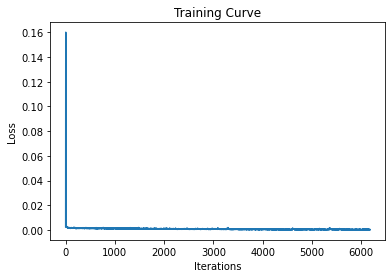

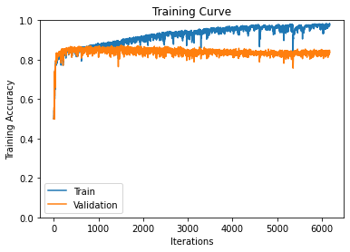

```
Final Training Accuracy: 0.9755809523809523
Final Validation Accuracy: 0.8357142857142857
```

```python
alexnet = torchvision.models.alexnet(pretrained=True)

# Transfer learning model with batch_size=256, learning_rate=0.005
model = HappyFaceClassifier_alex()

if use_cuda and torch.cuda.is_available():
  model.cuda()
  print('CUDA is available!  Training on GPU ...')
else:
  print('CUDA is not available.  Training on CPU ...')

# Training
train_updated(model, train_data, val_data, batch_size=256, learning_rate=0.005, num_epochs=30, checkpoint=False, transfer_learning=True, pretrained_model=alexnet)
```

### Try 2: batch size of 512, learning rate of 0.005

```
CUDA is available!  Training on GPU ...
Feature Extraction Started.
```

```
Feature Extraction Finished.
Training Started.
```

```
Epoch:  0  Train Acc:  0.7773142857142857  Valid Acc:  0.789795918367347
```

```
Epoch:  1  Train Acc:  0.8451428571428572  Valid Acc:  0.8530612244897959
```

```
Epoch:  2  Train Acc:  0.8512761904761905  Valid Acc:  0.8530612244897959
```

```
Epoch:  3  Train Acc:  0.8620761904761904  Valid Acc:  0.8642857142857143
```

```
Epoch:  4  Train Acc:  0.8631809523809524  Valid Acc:  0.863265306122449
```

```
Epoch:  5  Train Acc:  0.8772380952380953  Valid Acc:  0.8683673469387755
```

```
Epoch:  6  Train Acc:  0.8792952380952381  Valid Acc:  0.8561224489795919
```

```
Epoch:  7  Train Acc:  0.8714857142857143  Valid Acc:  0.8448979591836735
Training Finished.
Total time elapsed: 3206.08 seconds
```

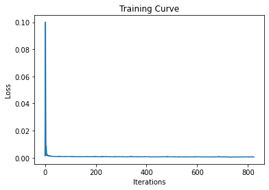

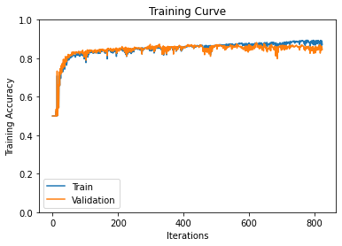

```
Final Training Accuracy: 0.8714857142857143
Final Validation Accuracy: 0.8448979591836735
```

```python
alexnet = torchvision.models.alexnet(pretrained=True)

# Transfer learning model with batch_size=512, learning_rate=0.005
model = HappyFaceClassifier_alex()

if use_cuda and torch.cuda.is_available():
  model.cuda()
  print('CUDA is available!  Training on GPU ...')
else:
  print('CUDA is not available.  Training on CPU ...')

# Training
train_updated(model, train_data, val_data, batch_size=512, learning_rate=0.005, num_epochs=8, checkpoint=True, transfer_learning=True, pretrained_model=alexnet)
```

```python
# Final transfer learning model with batch_size=512, learning_rate=0.005, epoch=5
alexnet = torchvision.models.alexnet(pretrained=True)
model = HappyFaceClassifier_alex()

if use_cuda and torch.cuda.is_available():
  model.cuda()

# get the best trained model
model_path = get_model_name(model.name, batch_size=512, learning_rate=0.005, epoch=5)
state = torch.load(model_path)
model.load_state_dict(state)

# feature extraction done using alexnet
train_feature_loader = get_feature_loader(alexnet, train_data, batch_size=512, num_workers=16)
val_feature_loader = get_feature_loader(alexnet, val_data, batch_size=512, num_workers=16)
test_feature_loader = get_feature_loader(alexnet, test_data, batch_size=512, num_workers=16)

# compute accuracy
train_acc = get_accuracy(model, train_feature_loader)
val_acc= get_accuracy(model, val_feature_loader)
test_acc = get_accuracy(model, test_feature_loader)

print("Transfer learning model with train acc of {0:.2f}, val acc of {1:.2f} has test acc {2:.2f} ".format(train_acc,val_acc,test_acc))
```

```
Transfer learning model with train acc of 0.88, val acc of 0.87 has test acc 0.75
```

# Part 3: GAN for Facial Expression Transfer

At this stage, we have strong classification performances, which means we can identify images of faces that are not happy with fairly high accuracy. The next step is to use a generative model to transfer a happy facial expression onto the images with not happy facial expressions.

We are using the PyTorch implementation of GANimation provided here (https://github.com/donydchen/ganimation_replicate) as a model. Currently, we have used the existing model in this repository to transfer facial expressions between images in our dataset. We have had promising results which show that a model like the one implemented in this repository could effectively transfer facial expressions as in the three images below.

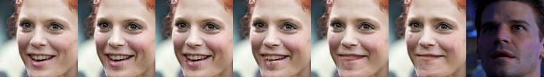

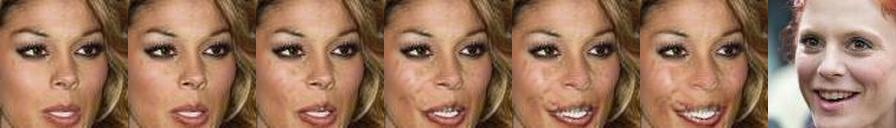

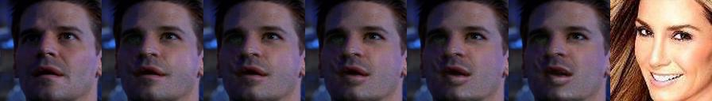

The next step after using the out-of-the-box repository architecture to show expression transfer was to begin to manipulate the architectue to optimize it for our specific task.

## Extracting Generator Model from GANimation

### Downloading and unzipping GANimation architecture

```python
!gdown --id '1Y-1r9uY8ciTUlj6-mUkn2MeKVoeMskts'
```

```
Downloading...
From: https://drive.google.com/uc?id=1Y-1r9uY8ciTUlj6-mUkn2MeKVoeMskts
To: /content/ganimation_replicate.zip
100% 2.10G/2.10G [00:20<00:00, 104MB/s]
```

```python
from google.colab import files
import zipfile
zip_ref = zipfile.ZipFile('/content/ganimation_replicate.zip', 'r')
zip_ref.extractall('/content')
zip_ref.close()
os.chdir("/content/ganimation_replicate/model")
```

### Loading existing generator model

```python
from base_model import BaseModel
from ganimation import GANimationModel

class Namespace:
    def __init__(self, **kwargs):
        self.__dict__.update(kwargs)

opt= Namespace(aus_nc=17, aus_pkl='aus_openface.pkl', batch_size=10, beta1=0.5, ckpt_dir='ckpts/celebA/ganimation/190327_161852/', data_root='datasets/celebA', epoch_count=1, final_size=128, gan_type='wgan-gp', gpu_ids=[], img_nc=3, imgs_dir='imgs', init_gain=0.02, init_type='normal', interpolate_len=5, lambda_aus=160.0, lambda_dis=1.0, lambda_mask=0, lambda_rec=10.0, lambda_tv=0, lambda_wgan_gp=10.0, load_epoch=30, load_size=148, log_file='logs.txt', lr=0.0001, lr_decay_iters=50, lr_policy='lambda', lucky_seed=1637713293, max_dataset_size=150, mode='test', model='ganimation', n_threads=6, name='211123_192133', ndf=64, ngf=64, niter=20, niter_decay=10, no_aus_noise=False, no_flip=False, no_test_eval=False, norm='instance', opt_file='opt.txt', plot_losses_freq=20000, print_losses_freq=100, resize_or_crop='none', results='results/celebA_ganimation_30', sample_img_freq=2000, save_epoch_freq=2, save_test_gif=False, serial_batches=False, test_csv='test_ids.csv', train_csv='train_ids.csv', train_gen_iter=5, use_dropout=False, visdom_display_id=0, visdom_env='main', visdom_port=8097)

model_path = '/content/ganimation_replicate/ckpts/celebA/ganimation/190327_161852/30_net_gen.pth'
state = torch.load(model_path)
```

### Showing structure of model

```python
os.chdir("/content/ganimation_replicate")
net = GANimationModel()
net.initialize(opt)
net = getattr(net, 'net_'+'gen')
net.load_state_dict(state)
print(net)
```

```
initialize network with normal
[Info] Successfully load trained weights for net_gen.
SplitGenerator(
  (model): Sequential(
    (0): Conv2d(20, 64, kernel_size=(7, 7), stride=(1, 1), padding=(3, 3))
    (1): InstanceNorm2d(64, eps=1e-05, momentum=0.1, affine=False, track_running_stats=False)
    (2): ReLU(inplace=True)
    (3): Conv2d(64, 128, kernel_size=(4, 4), stride=(2, 2), padding=(1, 1))
    (4): InstanceNorm2d(128, eps=1e-05, momentum=0.1, affine=False, track_running_stats=False)
    (5): ReLU(inplace=True)
    (6): Conv2d(128, 256, kernel_size=(4, 4), stride=(2, 2), padding=(1, 1))
    (7): InstanceNorm2d(256, eps=1e-05, momentum=0.1, affine=False, track_running_stats=False)
    (8): ReLU(inplace=True)
    (9): ResnetBlock(
      (conv_block): Sequential(
        (0): Conv2d(256, 256, kernel_size=(3, 3), stride=(1, 1), padding=(1, 1))
        (1): InstanceNorm2d(256, eps=1e-05, momentum=0.1, affine=False, track_running_stats=False)
        (2): ReLU(inplace=True)
        (3): Conv2d(256, 256, kernel_size=(3, 3), stride=(1, 1), padding=(1, 1))
        (4): InstanceNorm2d(256, eps=1e-05, momentum=0.1, affine=False, track_running_stats=False)
      )
    )
    (10): ResnetBlock(
      (conv_block): Sequential(
        (0): Conv2d(256, 256, kernel_size=(3, 3), stride=(1, 1), padding=(1, 1))
        (1): InstanceNorm2d(256, eps=1e-05, momentum=0.1, affine=False, track_running_stats=False)
        (2): ReLU(inplace=True)
        (3): Conv2d(256, 256, kernel_size=(3, 3), stride=(1, 1), padding=(1, 1))
        (4): InstanceNorm2d(256, eps=1e-05, momentum=0.1, affine=False, track_running_stats=False)
      )
    )
    (11): ResnetBlock(
      (conv_block): Sequential(
        (0): Conv2d(256, 256, kernel_size=(3, 3), stride=(1, 1), padding=(1, 1))
        (1): InstanceNorm2d(256, eps=1e-05, momentum=0.1, affine=False, track_running_stats=False)
        (2): ReLU(inplace=True)
        (3): Conv2d(256, 256, kernel_size=(3, 3), stride=(1, 1), padding=(1, 1))
        (4): InstanceNorm2d(256, eps=1e-05, momentum=0.1, affine=False, track_running_stats=False)
      )
    )
```

[output cut: 28 more lines]

```
    (16): InstanceNorm2d(128, eps=1e-05, momentum=0.1, affine=False, track_running_stats=False)
    (17): ReLU(inplace=True)
    (18): ConvTranspose2d(128, 64, kernel_size=(4, 4), stride=(2, 2), padding=(1, 1))
    (19): InstanceNorm2d(64, eps=1e-05, momentum=0.1, affine=False, track_running_stats=False)
    (20): ReLU(inplace=True)
  )
  (color_top): Sequential(
    (0): Conv2d(64, 3, kernel_size=(7, 7), stride=(1, 1), padding=(3, 3), bias=False)
    (1): Tanh()
  )
  (au_top): Sequential(
    (0): Conv2d(64, 1, kernel_size=(7, 7), stride=(1, 1), padding=(3, 3), bias=False)
    (1): Sigmoid()
  )
)
```

We are manipulating the generator model and have successfully loaded the model used in this repository to manipulate its architecture. Our next steps are to tune the architecture to work well for our specific purpose (generating only happy expressions) and to determine the best input to the discriminator based on our generator tuning.

```python
%%shell
jupyter nbconvert --to html /Team2ProgressUpdate.ipynb
```

[output not shown]